# Model Checking and Comparison

April 15, 2019

## Steps for Supervised Learning

1. Divide the observations you have into about 75% training and 25% testing
2. Solve an optimization problem in the training data for each candidate model
3. Predict the outcome in the testing data under each candidate model using the optimal parameters
4. Choose which model is best at predicting the testing outcome
- In addition, there is a preference for models that make weak assumptions about the functional form between the predictors and the outcomes so that the functional forms can be learned from the data
- In essence, they solve optimization problems (in the training data) like Frequentists do (in the sample) but make predictions about future observables rather than inferences about parameters
- If you do not care about making Frequentist inferences, you can (and should) add a penalty term to the (negated) log-likelihood when minimizing in (2)

## Supervised Learning & the Sources of Uncertainty

1. Uncertainty about parameters in models
2. Uncertainty about which model is best
3. Uncertainty about what to do with the output of the (best) model(s)
4. Uncertainty about whether the software works as intended
5. Uncertainty about extrapolating from the data you have to the data you want
- SL presumes (1) is negligible
- SL talks a lot about (2) but not in probabilistic terms
- SL has no formalization of (3) but does not question the heuristics much
- SL does its best to mitigate (4) but there are problems with complex models
- In SL, the data you want is from the future, which is proxied by the testing set

## The Transitivity of Optimality Fallacy

No one actually says:

```
The parameters that are optimal with respect to a (negated) penalized log-likelihood function
produce optimal predictions and thereby optimal decisions based on those predictions.
```

- But SL acts as if that must be true somehow
- What is true is Jensen's inequality: \(g\left(\mathbb{E}\widehat{\mathbf{y}}\right) \leq \mathbb{E}g\left(\widehat{\mathbf{y}}\right)\) for any convex function \(g\) with equality if and only if \(g\) is a linear function
- But SL acts as if the expectation of their predictive function (which need not be concave) is generally the same as the predictive function evaluated at the optimal parameters (which is not even an expectation)

## Bayesian Inference & the Sources of Uncertainty

1. Uncertainty about parameters in models
2. Uncertainty about which model is best
3. Uncertainty about what to do with the output of the (best) model(s)
4. Uncertainty about whether the software works as intended
5. Uncertainty about extrapolating from the data you have to the data you want
- For Bayesians, (1) is represented by (draws from) the posterior distribution
- We are going to learn about various Bayesian approaches to (2) today
- Bayesian inference is naturally connected to decision theory in (3)
- Stan does its best to mitigate (4) and warns you if it suspects problems
- Poststratification and leave-one-out cross-validation are two techniques for (5)

## Approaches to Bayesian Model Comparison

There is a lot of disagreement among Bayesians about how to compare models:

1. Do not compare models; obtain the posterior distribution of the parameters in an encompassing model
2. Use Bayes Rule to produce a posterior probability that each model \(j\) is true, conditional on one of the \(J\) models being considered is true. This essentially amounts to asking which of the \(J\) prior predictive distributions best predicted the data being conditioned on
3. Which of the \(J\) posterior predictive distributions is expected to best predict future data? Or find the best weighted sum of thereof.
4. Do (1) but then find a submodel that is essentially as good on (3)

## Restricted Cubic Splines

- Splines are one way to allow the linear predictor to be a non-linear function of the predictor(s) while remaining a linear function of the coefficients
- In regressions, splines work by taking one predictor and expanding functions of it into several columns of a design matrix that are weighted by coefficients
- Restricted Cubic Splines are linear before the first and after the last "knot" but cubic between the first and last knots
- The knots are usually equally spaced over the quantiles of the predictor
- For details and formulas, see the [Stata Reference Manual](https://www.stata.com/manuals13/rmkspline.pdf#rmksplineMethodsandformulasRestrictedcubicsplines)

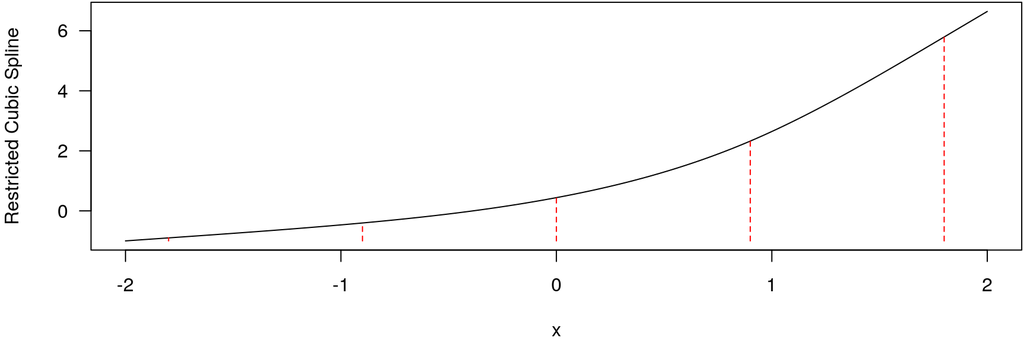

## Restricted Cubic Splines in the Stan Language

```stan
functions {
  vector cube_pos(vector u) {
    vector[rows(u)] out;
    for (n in 1:rows(u)) out[n] = u[n] > 0 ? u[n] : 0;
    out .*= square(out); // ^^^ is like ifelse() in R
    return out;
  }

  matrix rcs(vector V, vector k) {
    int N = rows(V);
    int n = rows(k);
    matrix[N, n - 1] out;
    real denom = square(k[n] - k[1]);
    real kn_knm1 = k[n] - k[n - 1];
    out[ , 1] = V;
    /* finish the rest with a loop that calls cube_pos() */
    return out;
  }
}
```

## Estimating an Encompassing Model

- Don't know if a relationship is linear, quadratic, or something in between?
- No problem, estimate a spline with something like

```r
download.file("http://ceprdata.org/wp-content/cps/data/cepr_march_2016.zip",
              "cepr_march_2016.zip")
library(haven)
CPS <- as_factor(read_dta("cepr_march_2016.zip"))
CPS <- dplyr::filter(CPS, hrwage > 0, !is.na(age), state == "New York")
CPS <- CPS[order(CPS$age), ]
rstan::expose_stan_functions("rcs.stan")
CPS <- cbind(CPS, age_rcs =
               rcs(CPS$age, k = quantile(CPS$age, probs = c(.05, .275, .5, .725, .95))))
library(rstanarm)
options(mc.cores = parallel::detectCores())
library(bayesplot)
```

```r
post_1 <- stan_lm(log(hrwage) ~ age_rcs.1 + age_rcs.2 + age_rcs.3 + age_rcs.4,
                  data = CPS, prior = R2(0.15, what = "median")) # warnings
```

## Plot of Relationship between Wages and Age

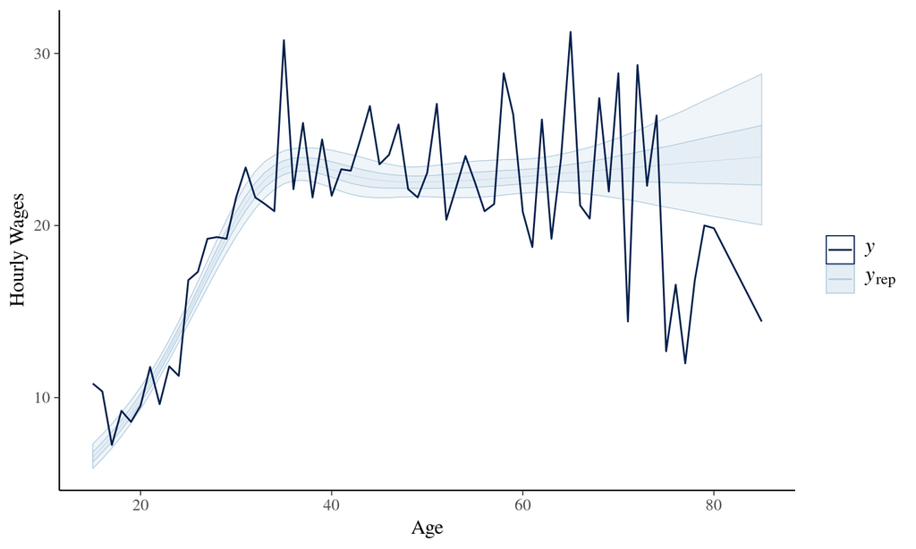

```r
ppc_ribbon(y = with(CPS, ave(hrwage, age, FUN = median)), x = CPS$age,
           yrep = exp(posterior_linpred(post_1, transform = TRUE))) +
  ggplot2::ylab("Hourly Wages") + ggplot2::xlab("Age")
```

## Posterior Predictive Checks

- The previous plot is shows the relationship between the conditional (on age) expectation function vs. observed wage medians (by age)
- "If our model is a good fit then we should be able to use it to generate data that looks a lot like the data we observed." (which includes noise)
- The posterior predictive distribution of future data \(\widetilde{y}_{N + 1}, \widetilde{y}_{N + 2}, \dots, \widetilde{y}_{2N}\) conditional on past data \(y_1, y_2, \dots, y_N\) can be obtained via the Bayesian Hokey Pokey \[f\left(\widetilde{y}_{N + 1}, \widetilde{y}_{N + 2}, \dots, \widetilde{y}_{2N} \mid y_1, y_2, \dots, y_N\right) = \\ \int_\Theta f\left(\widetilde{y}_{N + 1}, \widetilde{y}_{N + 2}, \dots, \widetilde{y}_{2N} \mid \boldsymbol{\theta}\right) f\left(\boldsymbol{\theta} \mid y_1, y_2, \dots, y_N\right) d\theta_1 d\theta_2 \dots d\theta_K\]

## Posterior Predictive Checks in Practice

- In practice, posterior predictive distribution can be obtained by repeatedly
1. Drawing \(\widetilde{\boldsymbol{\theta}}\) from the posterior distribution of \(\boldsymbol{\theta}\) given \(y_1, y_2, \dots, y_N\)
2. Using \(\widetilde{\boldsymbol{\theta}}\) to draw from the distribution of \(\widetilde{y}_{N + 1}, \widetilde{y}_{N + 2}, \dots, \widetilde{y}_{2N}\) given \(\boldsymbol{\theta}\)
- Since we do not have future data (yet), we can compare that to past data
- `launch_shinystan(post_1)`

## Programmatic Plots with **bayeplot**

```r
format(available_ppc())
```

```
##  [1] "ppc_bars                  " "ppc_bars_grouped          "
##  [3] "ppc_boxplot               " "ppc_data                  "
##  [5] "ppc_dens                  " "ppc_dens_overlay          "
##  [7] "ppc_ecdf_overlay          " "ppc_error_binned          "
##  [9] "ppc_error_hist            " "ppc_error_hist_grouped    "
## [11] "ppc_error_scatter         " "ppc_error_scatter_avg     "
## [13] "ppc_error_scatter_avg_vs_x" "ppc_freqpoly              "
## [15] "ppc_freqpoly_grouped      " "ppc_hist                  "
## [17] "ppc_intervals             " "ppc_intervals_data        "
## [19] "ppc_intervals_grouped     " "ppc_loo_intervals         "
## [21] "ppc_loo_pit               " "ppc_loo_pit_overlay       "
## [23] "ppc_loo_pit_qq            " "ppc_loo_ribbon            "
## [25] "ppc_ribbon                " "ppc_ribbon_data           "
## [27] "ppc_ribbon_grouped        " "ppc_rootogram             "
## [29] "ppc_scatter               " "ppc_scatter_avg           "
## [31] "ppc_scatter_avg_grouped   " "ppc_stat                  "
## [33] "ppc_stat_2d               " "ppc_stat_freqpoly_grouped "
## [35] "ppc_stat_grouped          " "ppc_violin_grouped        "
```

## Overlaid Density Plots

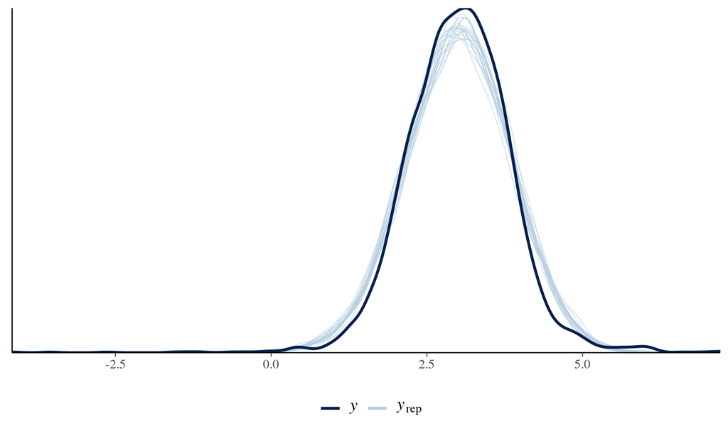

```r
pp_check(post_1, plotfun = "dens_overlay", nreps = 20) + legend_move("bottom")
```

## Scatterplots

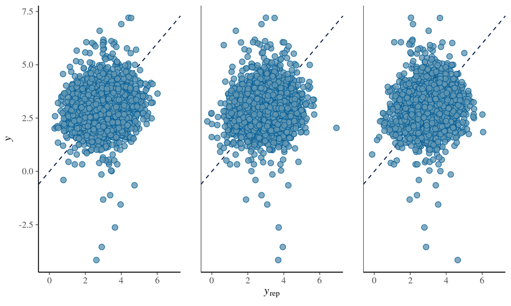

```r
pp_check(post_1, plotfun = "scatter")
```

## Frequency Polygons with Grouping

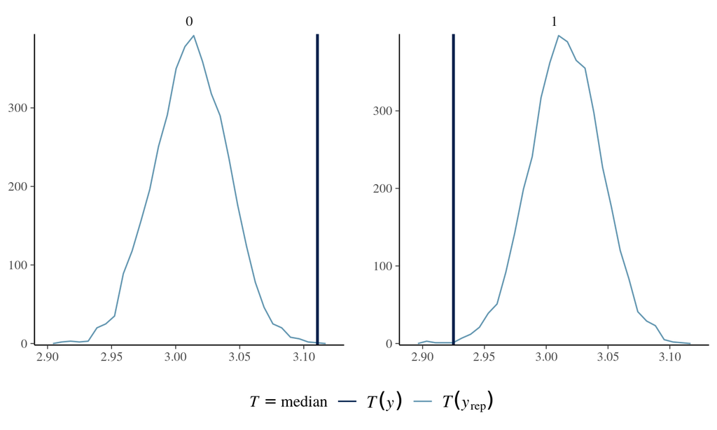

```r
pp_check(post_1, plotfun = "stat_freqpoly_grouped", group = CPS$female, stat = "median") +
  legend_move("bottom")
```

## Ridges

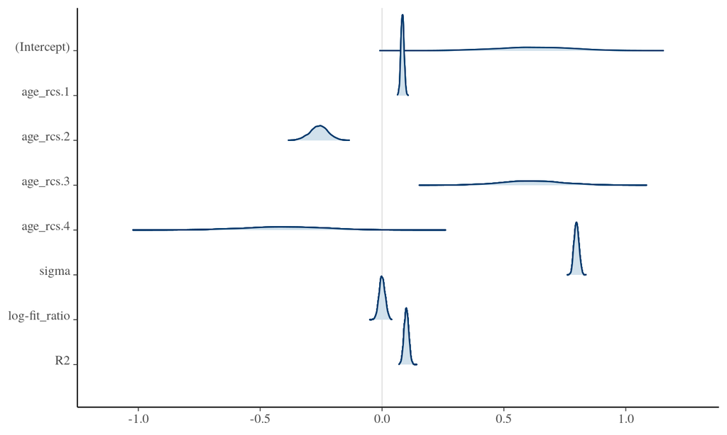

```r
mcmc_areas_ridges(as.matrix(post_1))
```

## Hexograms

[figure not shown]

```r
mcmc_hex(as.matrix(post_1), pars = c("age_rcs.1", "age_rcs.2"))
```

## Pairs

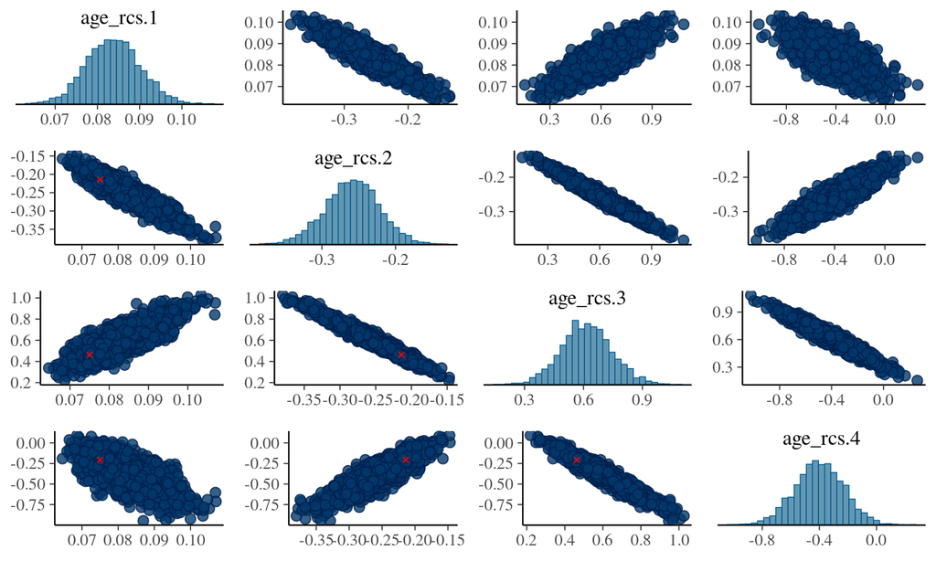

```r
pairs(post_1, regex_pars = "age")
```

## Parallel Coordinates

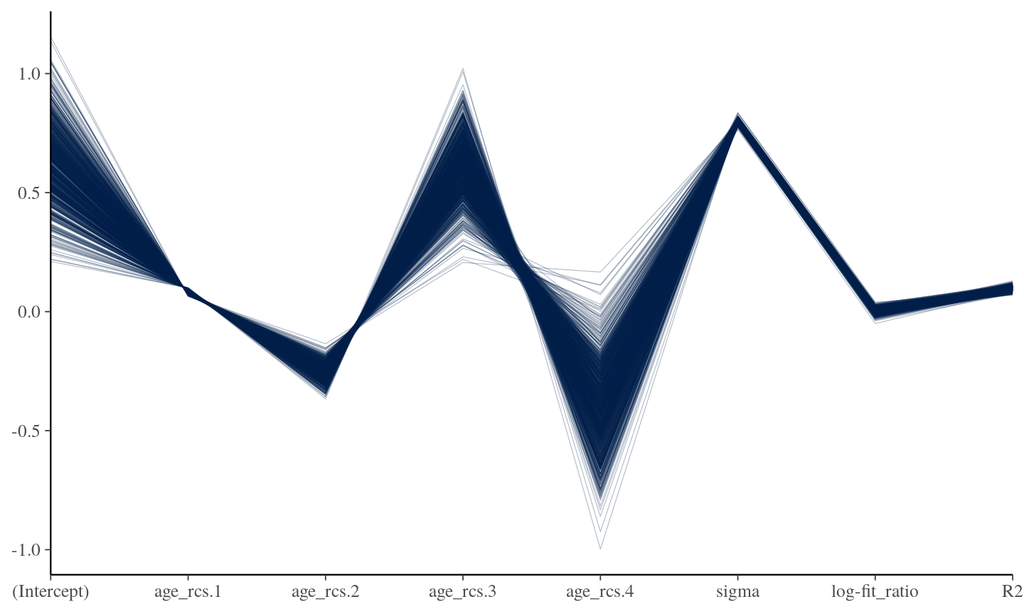

```r
mcmc_parcoord(as.matrix(post_1), np = nuts_params(post_1))
```

## Leave One Out Cross-Validation (LOOCV)

- Not splitting the dataset into training and testing really bothers supervised learning people, but we can mitigate their objections
- Correct Bayesian utility function for predictions is the expectation (over future data) of the logarithm of the posterior predictive PDF
- Can consistently estimate \[\mathbb{E} \ln f\left(\widetilde{y}_{N + 1}, \widetilde{y}_{N + 2}, \dots, \widetilde{y}_{2N} \mid y_1, y_2, \dots, y_N\right) = \\ \sum_{n = N + 1}^{2N} \mathbb{E}\ln f\left(y_n \mid y_1, y_2, \dots y_N\right)\] using only past data with \(\sum_{n = 1}^{N} \ln f\left(y_n \mid \mathbf{y}_{-n}\right)\)
- SL does something similar with \(K\)-fold cross-validation if you let \(K = N\)

## ELPDPSISLOOCV

```r
loo(post_1)
```

```
##
## Computed from 4000 by 3398 log-likelihood matrix
##
##          Estimate    SE
## elpd_loo  -4059.6  83.9
## p_loo         9.1   1.4
## looic      8119.3 167.7
## ------
## Monte Carlo SE of elpd_loo is 0.1.
##
## All Pareto k estimates are good (k < 0.5).
## See help('pareto-k-diagnostic') for details.
```

- `looic` is \(-2 \times\) `elpd_loo` to put it in the same units as AIC, DIC, WAIC, etc.
- `p_loo` is an estimate of the effective number of parameters estimated, which can differ from the nominal number of parameters due to priors

## Model Comparison via ELPDPSISLOOCV

```r
post_2 <- stan_lm(log(hrwage) ~ age, data = CPS, prior = R2(0.15, what = "median"))
```

```r
loo_compare(loo(post_1), loo(post_2))
```

```
##        elpd_diff se_diff
## post_1   0.0       0.0
## post_2 -95.6      13.9
```

```r
loo_model_weights(stanreg_list(post_1, post_2)) # weight each model's predictions by this
```

```
## Computing approximate LOO-CV (models do not already have 'loo' components).
```

```
## Method: stacking
## ------
##        weight
## post_1 0.951
## post_2 0.049
```

## Using LOO with Posterior Predictive Checks

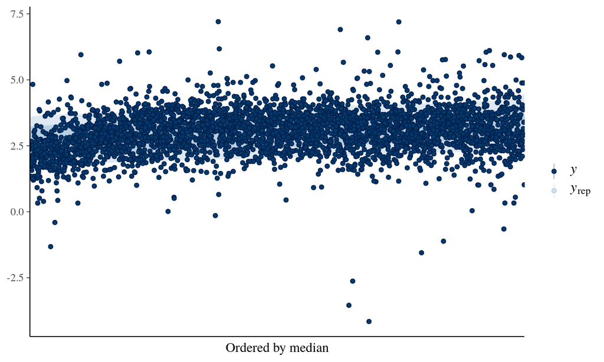

```r
pp_check(post_2, plotfun = "loo_intervals", order = "median", prob_outer = 0.75, size = 0.1)
```

## Numerical Assessment of Overfitting

```r
PPD <- posterior_predict(post_1)
PPD_loo <- t(loo::E_loo(PPD, psis_object = loo(post_1, save_psis = TRUE)$psis,
                        type = "quantile", probs = c(0.25, 0.75),   # IQR as the interval
                        log_ratios = -log_lik(post_1))$value)
mean(get_y(post_1) > PPD_loo[ , 1] & get_y(post_1) < PPD_loo[ , 2]) # some overfitting
```

```
## [1] 0.5670983
```

## Using LOO Probability Integral Transform

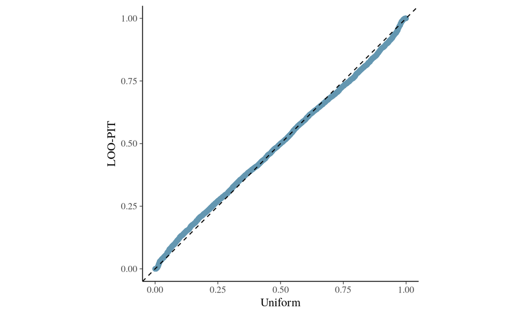

```r
pp_check(post_2, plotfun = "loo_pit_qq")
```

## Penalization vs. Priors

- (Mis)fit function used in supervised learning is proportional to a log-likelihood
- Supervised learning often adds a penalization function on the coefficients to the extent they are not zero
- Sum of these is often a posterior log-kernel for some choice of [prior](https://osf.io/4ev8h/)

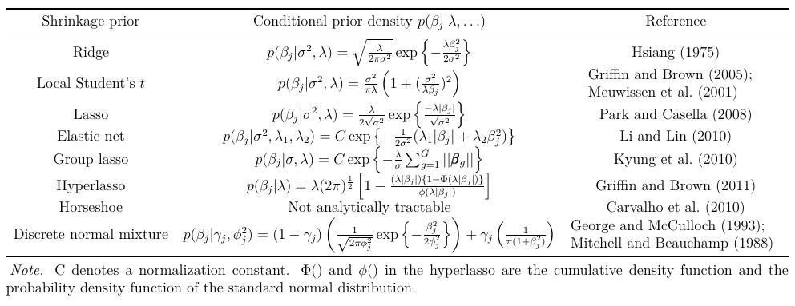

## Comparison to Lasso

- The Lasso method chooses coefficients to minimize the penalized objective function \[\sum_{n=1}^N\left(y_n - \widehat{y_n\left(\boldsymbol{\beta}\right)}\right)^2 + \lambda \sum_{k=1}^K\left|\beta_k\right|\]
- That is proportional to the negative posterior kernel with \(\sigma = 1\), a Gaussian likelihood, and independent Laplace priors on the coefficients with location zero and FIXED inverse scale \(\lambda\)
- The Laplace distribution is the maximum entropy distribution for a real random variable under the constraint \(\mathbb{E}\left|\beta\right| = \frac{1}{\lambda}\)
- Posterior MODE corresponds to the Lasso solution for a given \(\lambda\)
- Only recently did the Tibshiranis (and co-authors) [derive](http://statweb.stanford.edu/~tibs/ftp/covtest-talk.pdf) a sampling distribution for the Lasso point estimator

## Logit Model, No Intercept, Single Coefficient

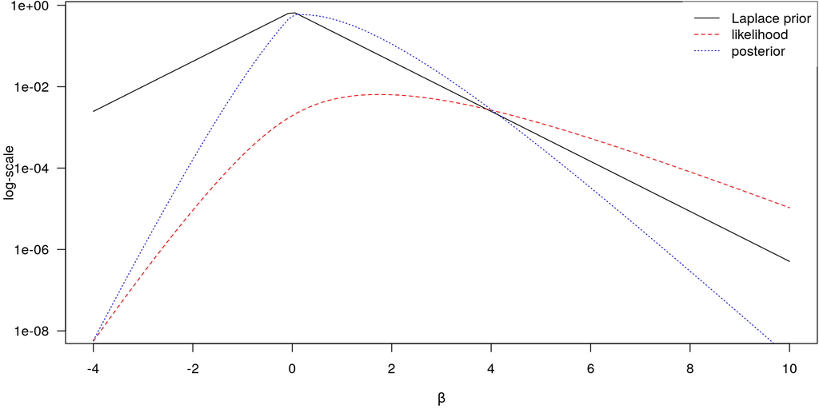

## Bayesianism vs. Supervised Learning

- Penalty functions used in SL make for [poor priors](https://statmodeling.stat.columbia.edu/2017/11/02/king-must-die/) because they are intended to shift the mode rather than reflect beliefs
- But (most of) SL does not attempt to quantify the uncertainty in parameters or model choice
- Bayesians keep track of uncertainty of everything as best they can
- SL fixes hyperparameters to whatever predicts best in the testing data
- Bayesians want to condition on all available information
- Nevertheless, you could do something like

```r
stan_glm(formula(post_1), data = CPS, family = gaussian, prior = lasso())
```

## Finnish Horseshoe Priors

- When "testing" that a coefficient is zero or estimating an exploratory model with tons of predictors, you often need stronger priors
- The Laplace prior is not that good for various reasons and tends not to yield posterior means / medians that are near zero; see [here](https://betanalpha.github.io/assets/case_studies/bayes_sparse_regression.html)
- The Finnish Horseshoe prior is, for a given \(v\), \(s^2\), and \(t\) \[\beta_k \thicksim \mathcal{N}\left(0,\tau \overline{\lambda_k}\right)\\ \overline{\lambda_k} = \frac{c\lambda_k}{\sqrt{c^2 + \tau^2 \lambda_k^2}}\\ \lambda_k \thicksim \mbox{Cauchy}_+\left(0,1\right)\\ c^{-2} \thicksim \mbox{Gamma}\left(\frac{v}{2}\frac{v}{2}s^2\right)\\ \tau \thicksim \mbox{Cauchy}_+\left(0,t\right)\]

## Finnish Horseshoe Prior Predictive Distribution

```stan
functions { /* saved as FH_PPD_rng.stan */
  vector FH_PPD_rng(real t, real v,
                    real ss, real rate,
                    vector x) {
    // draw once from prior PD for each value of x
    // can ignore the intercept
  }
}
```

## Finnish Horseshoe Prior in **rstanarm**

```r
t <- 5 / (13 - 5) * 1 / sqrt(nrow(CPS)) # guess 5 out of 13 != 0
my_prior = hs(global_scale = t, slab_scale = 1)
FHP <- stan_glm(log(hrwage) ~ age_rcs.1 + age_rcs.2 + age_rcs.3 + age_rcs.4 +
                  female + citizen + pubsect + educ + rural,
                data = CPS, family = gaussian, prior_PD = TRUE, prior = my_prior)
```

- By specifying `prior_PD = TRUE` Stan will not condition on the data and thus the "posterior" distribution it draws from is just the prior distribution

## Visualizing the Finnish Horseshoe Prior

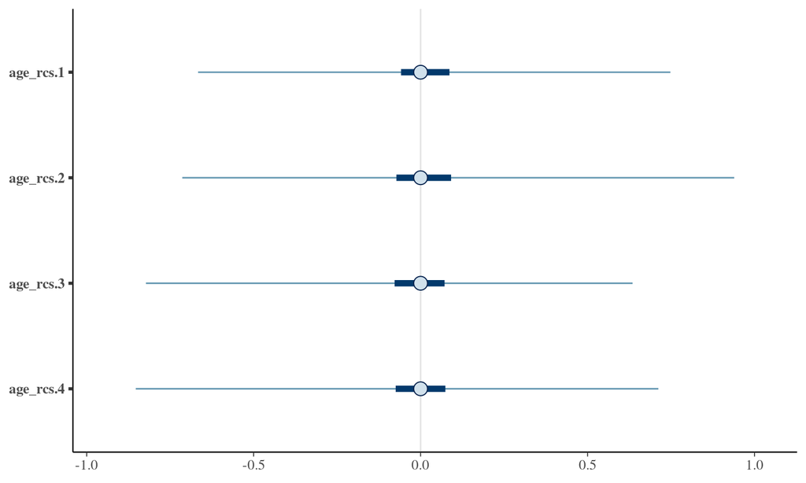

```r
plot(FHP, regex_pars = "age", prob = 0.99)
```

## Product-Normal Priors

- The product-normal distribution is the distribution of a product of two (or \(n\)) normal random variables each with an expectation of zero
- The PDF is difficult to write in a useful form but [Gaunt 2016](https://arxiv.org/pdf/1309.4344.pdf) shows that \[x \rightarrow 0: f\left(x \mid n, \sigma_1, \sigma_2, \dots, \sigma_n\right) \rightarrow \frac{\left(-\ln\frac{\mid x \mid}{\sigma}\right)^{n - 1}} {\left(2 \pi\right)^{\frac{n}{2}}\left(n - 1\right)!\sigma}\] \[x \rightarrow \infty: f\left(x \mid n, \sigma_1, \sigma_2, \dots, \sigma_n\right) \rightarrow \frac{2^{\frac{n}{2} - 1}}{\sigma\sqrt{n\pi}}\left(\frac{\mid x \mid}{\sigma}\right)^{\frac{1}{n} - 1} e^{-\frac{n}{2}\left(\frac{\mid x \mid}{\sigma}\right)^{\frac{2}{n}}}\] where \(\sigma = \prod_{i = 1}^n \sigma_i\)
- In short, the PDF approaches \(\infty\) as \(x \rightarrow 0\) but the tails are heavy

## Product-Normal when \(n = 2\) & \(\sigma_1 = 1 = \sigma_2\)

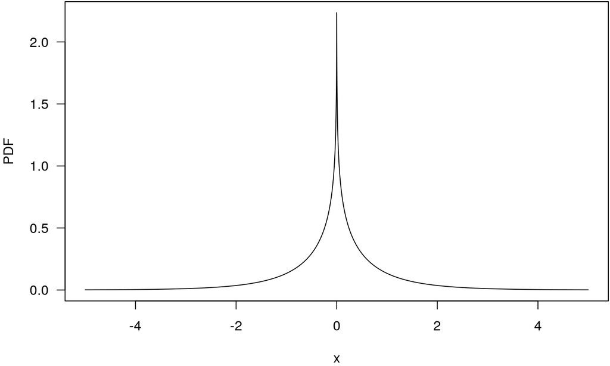

```r
curve(besselK(nu = 0, abs(x)) / pi, from = -5, to = 5, n = 10001, las = 1, ylab = "PDF")
```

## Product-Normal Priors in **rstanarm**

```r
CPS_noNA <- CPS[ , c("hrwage", "age_rcs.1", "age_rcs.2", "age_rcs.3", "age_rcs.4",
                     "female", "citizen", "pubsect", "educ", "rural")]
post_3 <- update(FHP, data = CPS_noNA,
                 prior = product_normal(df = 2, scale = 0.25), prior_PD = FALSE)
```

## Projection Pursuit

- "Sparsity is an input to your utility function, not an assumption to impose on the posterior distribution" – Rob McCulloch (quoting someone else)

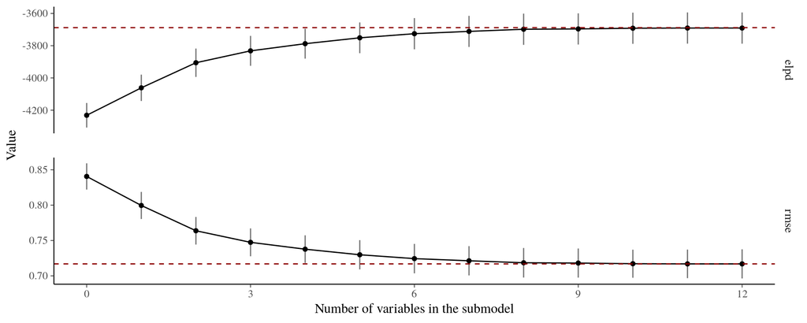

```r
library(projpred); fit_vs <- varsel(post_3); varsel_plot(fit_vs, stats = c('elpd', 'rmse'))
```

## Selecting a Submodel with a Subset of Predictors

```r
cvs <- cv_varsel(post_3, method = 'forward', verbose = FALSE); suggest_size(cvs)
```

```
## [1] 12
```

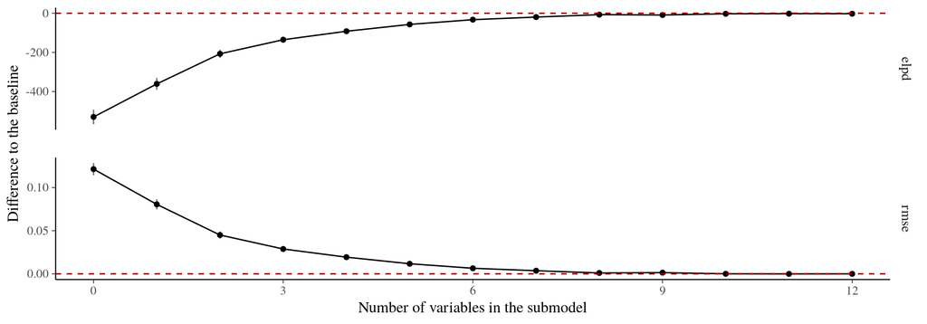

```r
varsel_plot(cvs, stats = c('elpd', 'rmse'), deltas = TRUE)
```

## Vizualizing the Submodel

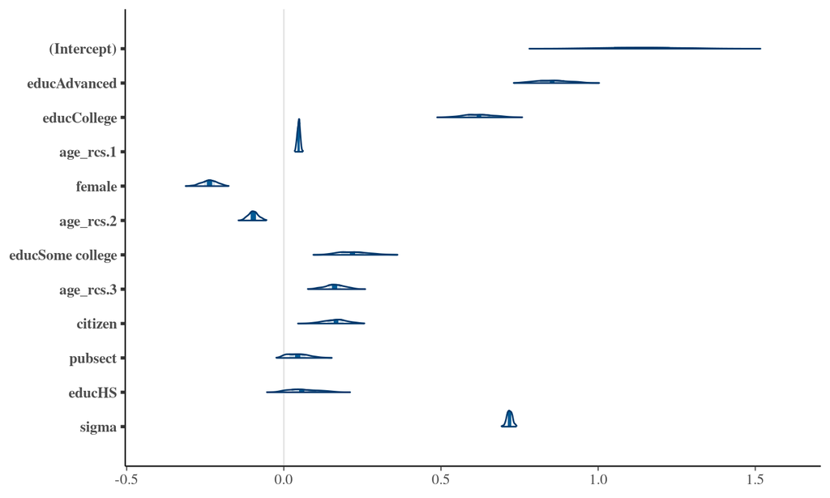

```r
mcmc_areas(as.matrix(project(fit_vs, nv = 10)), # see also proj_{linpred,predict}()
           pars = c('(Intercept)', names(fit_vs$vind[1:10]), 'sigma'))
```

## Bridge Sampling for Model Probabilities

```r
post_1 <- update(post_1, diagnostic_file = "post_1.csv")
post_2 <- update(post_2, diagnostic_file = "post_2.csv")
library(bridgesampling)
bridge_post_1 <- bridge_sampler(post_1)
bridge_post_2 <- bridge_sampler(post_2)
```

```r
em_1 <- error_measures(bridge_post_1) # make sure that these are ...
em_2 <- error_measures(bridge_post_2)  # ... small before calling post_prob
post_prob(bridge_post_1, bridge_post_2)
```

```
## bridge_post_1 bridge_post_2
##  1.000000e+00  6.096687e-42
```